# report

NBA Awards Prediction

## Introduction

This report details the methodology, implementation, and results of a predictive modeling project aimed at forecasting the end-of-season All-NBA and All-Rookie teams.

## All-NBA and All-Rookie Teams

The All-NBA Team is an annual honor bestowed upon the best players in the National Basketball Association (NBA) following every regular season. Voted on by a global panel of sportswriters and broadcasters, the honor is divided into three distinct five-man lineups: the First, Second, and Third teams.

Similarly, the All-Rookie Team honors the top performing first-year players in the league. Voted on by NBA head coaches, this distinction is divided into two five-man lineups: the First and Second teams.

## Metric

To evaluate the model’s prediction performance, a custom, point-based scoring system is utilized.

Points are awarded per player based on the following criteria:

Exact Match: **10 points** (The player is placed in the correct team). Off by One: **8 points** (The player is placed one team above or below their actual result). Off by Two: **6 points** (The player is placed two teams above or below their actual result). Un-nominated: **0 points**

To further reward highly accurate models, cumulative bonus points are awarded for correctly predicting multiple players within the same specific exact lineup: 2 correct players: +5 points 3 correct players: +10 points 4 correct players: +20 points 5 correct players: +40 points

Maximum Possible Score & Normalization A perfect prediction for a single team (5 players at 10 points each, plus the 40-point completion bonus) yields exactly 90 points. Across the five target teams, a perfect sweep results in 450 points.

## Approach

The predictive modeling approach is formulated as a *regression* problem, where the model is trained to predict a *vote share*. This is a `0-1` percentage value, which is used to create a ranking of players. The top 5 players are then selected as the predicted team for each category (All-NBA and All-Rookie).

### Sparsity

One of the problems with the data is the sparsity of votes. Almost *all* players receive `0` votes, and only a small fraction of players receive any votes at all. This creates a highly imbalanced dataset, which can be challenging for traditional regression models to learn from effectively.

To tackle this issue, a **hurdle regression** approach is implemented. This involves first training a **binary classifier** to predict probabilities whether a player receives any votes (i.e., whether they are nominated or not). Then, for the a separate regression model is trained to predict their vote share. This two-step process helps to mitigate the effects of sparsity and allows the model to focus on learning from the relevant subset of data.

The comparison to a standard regression model is included in *Experiments* section below.

### Code

The hurdle regression is implemented in `src/pipeline.py`

## Data Acquisition

Despite available official nba stat apis, the task of gathering data was very painstaking.

To gather league statistics, the `nba_api` package was used [[link][(https://github.com/swar/nba_api). However, the package do not provide access to the voting data.

Both basic and advanced statistics were collected, ensuring they are taken from regular season, and not from the playoffs, as the voting is based on regular season performance.

Additionaly, column regarding team position in the final season ranking was added as an additional feature

The voting data was scraped from the basketball reference website [[link][(https://www.basketball-reference.com/awards/awards_2023.html). This process involved writing custom web scraping scripts to extract the relevant information from the HTML pages

Finally the data was cleaned and preprocessed in `R` as it is much more convenient and superior than `python` for tabular data manipulation and cleaning. The cleaned data was then exported to `dataset/final_ml_dataset.csv` file

### Feature selection

The following features were selected for the model: 0. PTS_RANK: A team or player’s league-wide ranking based on their average points scored per game. 0. PIE_RANK: A ranking based on the Player Impact Estimate (PIE), indicating an entity’s overall statistical contribution compared to the rest of the league. 0. PLUS_MINUS_RANK: The league ranking of a player’s or team’s average point differential (Plus/Minus) while they are on the court. 0. W_PCT_RANK: A team’s rank based on their win percentage during the regular season. 0. PTS: The average number of points scored per game. 0. REB: The average number of total rebounds (offensive plus defensive) collected per game. 0. AST: The average number of assists distributed per game, representing passes that directly lead to a scored basket. 0. STL: The average number of steals recorded per game by legally taking the ball away from an opponent. 0. BLK: The average number of blocked shots per game where a defensive player legally deflects a field goal attempt. 0. USG_PCT: Usage Percentage estimates the percentage of team plays used by a specific player while they are on the floor. 0. TS_PCT: True Shooting Percentage measures overall shooting efficiency by factoring in the value of two-point field goals, three-point field goals, and free throws. 0. PlayoffRank: A team’s current standing or projected seed within their respective conference for playoff qualification. 0. WinPCT: The ratio of games won to total games played, representing the team’s overall winning percentage. 0. TD3: The total number of triple-doubles achieved, which occurs when a player accumulates double digits in three of the five major statistical categories in a single game. 0. GP: The total number of games played by a player or team during the specified season. 0. IS_ROOKIE: A boolean or binary flag indicating whether a player is in their first active season in the NBA.

### Feature standardization

Because absolute value features (e.g., points, rebounds) are not directly comparable across different seasons due to changes in the style of play and league dynamics, they were standardized using league-wide rankings. This approach allows for a more consistent comparison of player performance across different eras.

### Code

1. Obtaining league statistics: `src/data/get_league_stats.py`
2. Scraping voting data: `src/data/scrape_voting_data.py`
3. Data cleaning and preprocessing: `src/data/preprocessing.R`

### Problems

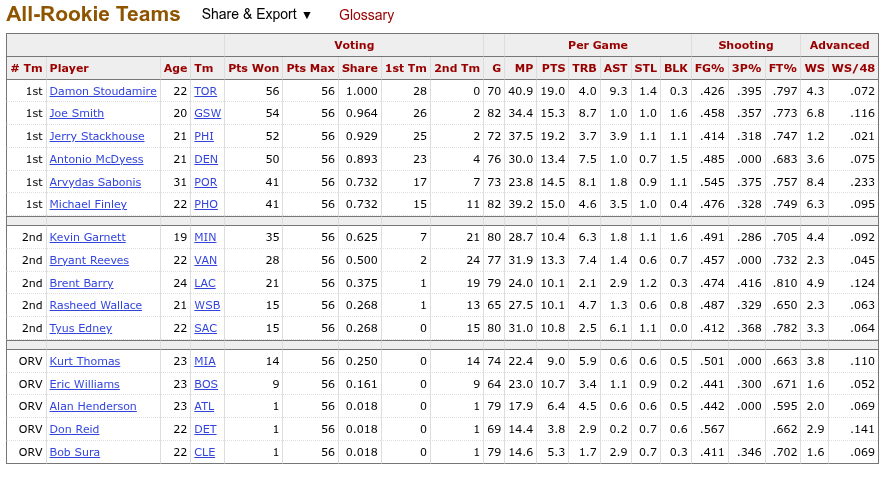

The same situation happened in 2007

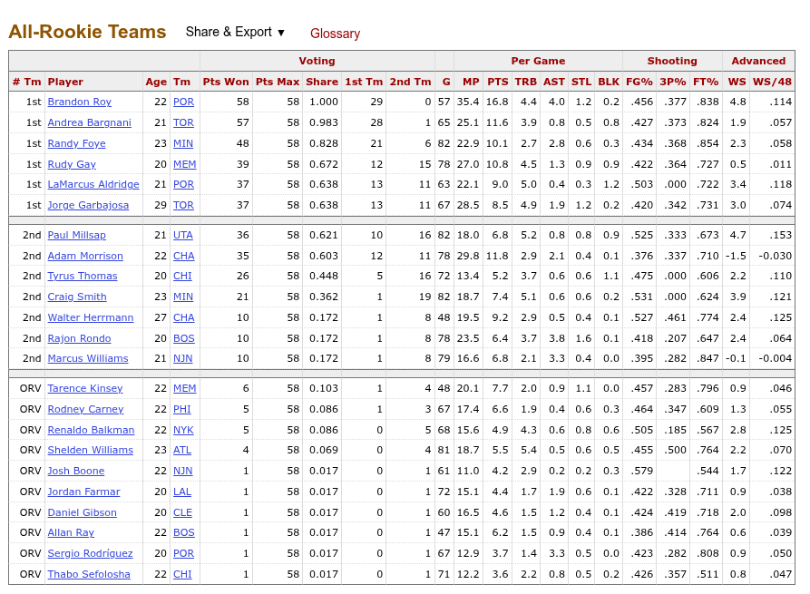

[figure not shown]

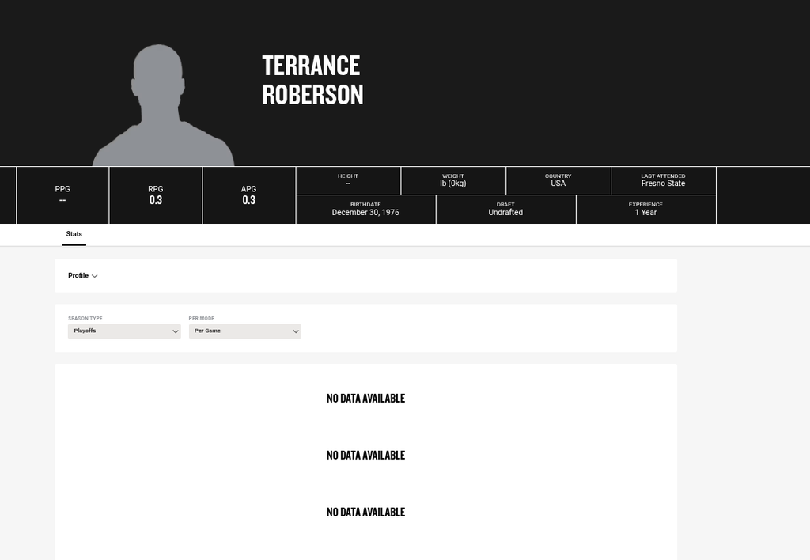

**Missmatch in names between stats and voting data** The scraped thata do not contain `PLAYER_ID` so it had to be obtained by matching the player names in the voting data with the player names in the stats data.

Sometimes, the names do not match exactly, so different heuristics were implemented including removing utf-8 characters, matching only the last name etc.

All heuristics matches were logged as warnings and validated manually.

## Pipeline

The whole process was implemented in `sklearn` pipeline, which includes the following steps: 1. Selecting appropriate features 2. Regularization of the appropriate features 3. Predicting probabilities of being nominated using a binary classifier 4. Predicting vote share using a regression model 5. Scaling the predicted vote share by the predicted probabilities of being nominated

## Experiments

I wanted to check the following:

1. How does excluding old seasons affect the performance of the model? In the past the game were different, and the voting criteria change as well
2. Is the classification step neccessary, if so how different classification models perform?
3. How do different regression models perform?

## Validation

The validation was performed on the `2026` season, which is the most recent season for which the voting data is available. The model was trained on all previous seasons, and then used to predict the All-NBA and All-Rookie teams for the `2026` season. The predicted teams were then compared to the actual teams using the scoring system described in the *Metric* section above.

Probably this is not the most reliable validation strategy, but unfortunately, the rules for selecting the All-NBA and All-Rookie teams changed in 2023, which makes it difficult to use older seasons for validation. The new rules eliminate the requirement for diverse positions across the 5 players in the same team, as well as the recent minimum games played requirement, which significantly changes the voting dynamics and criteria.

## Results

**The best score `375` for `2026` season was achieved by the Gradient Boosting Regressor with the classification by Logistic Regression.**

### Analysis

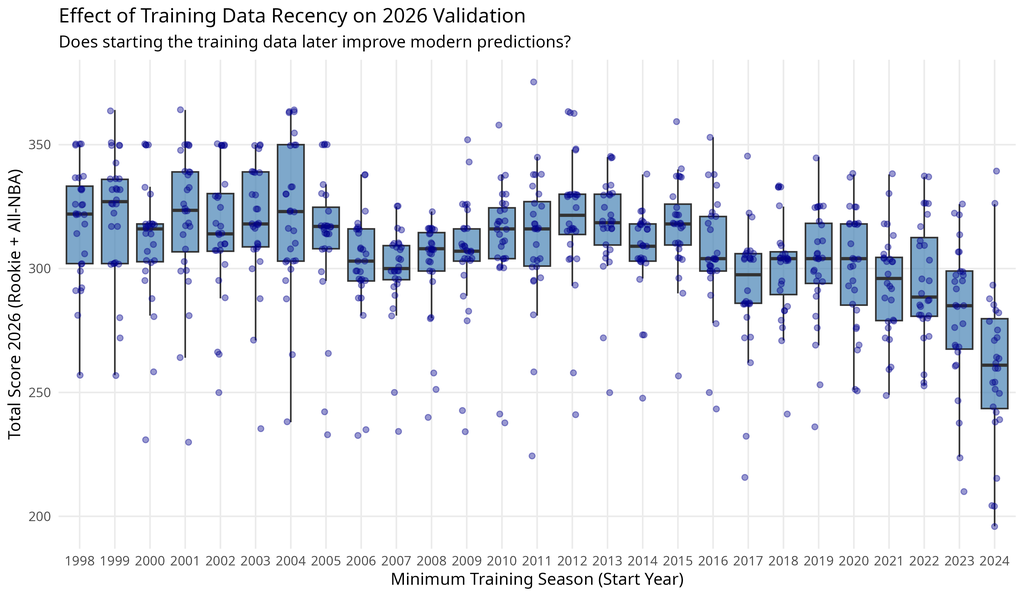

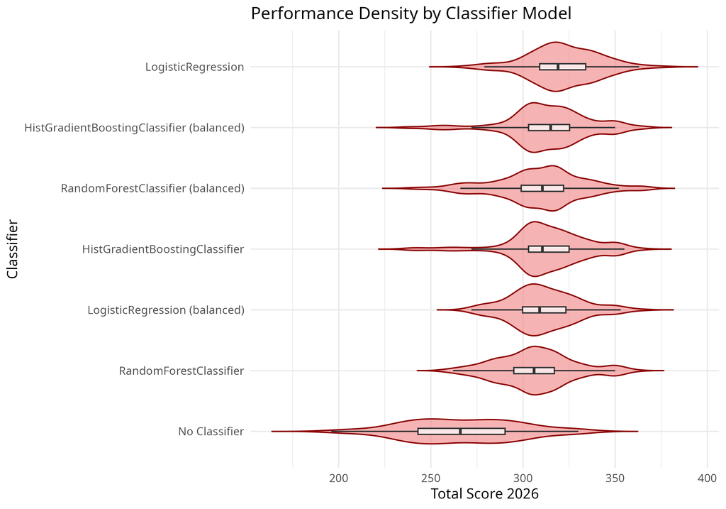

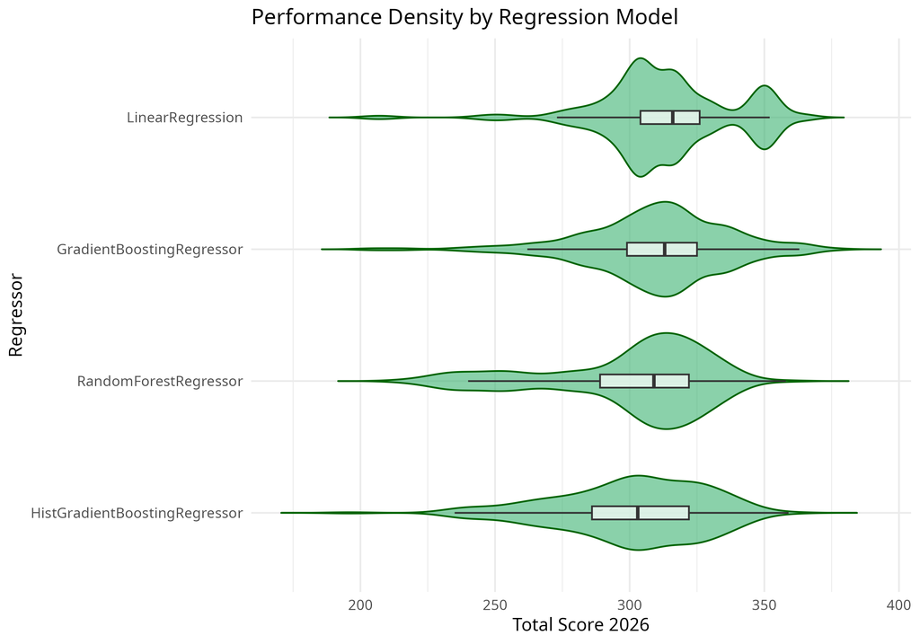

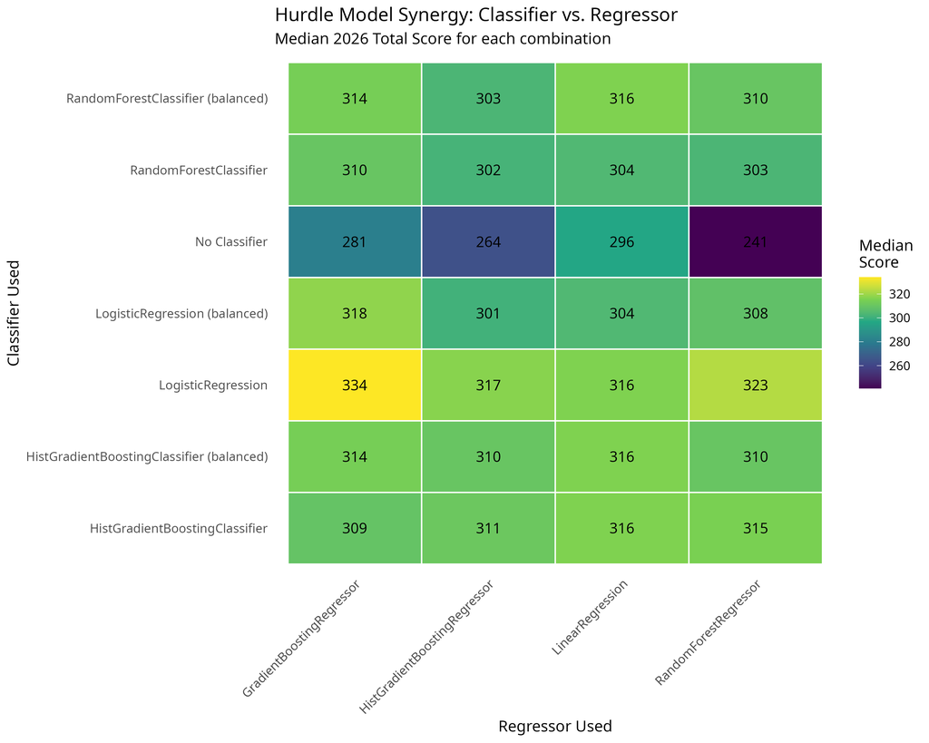

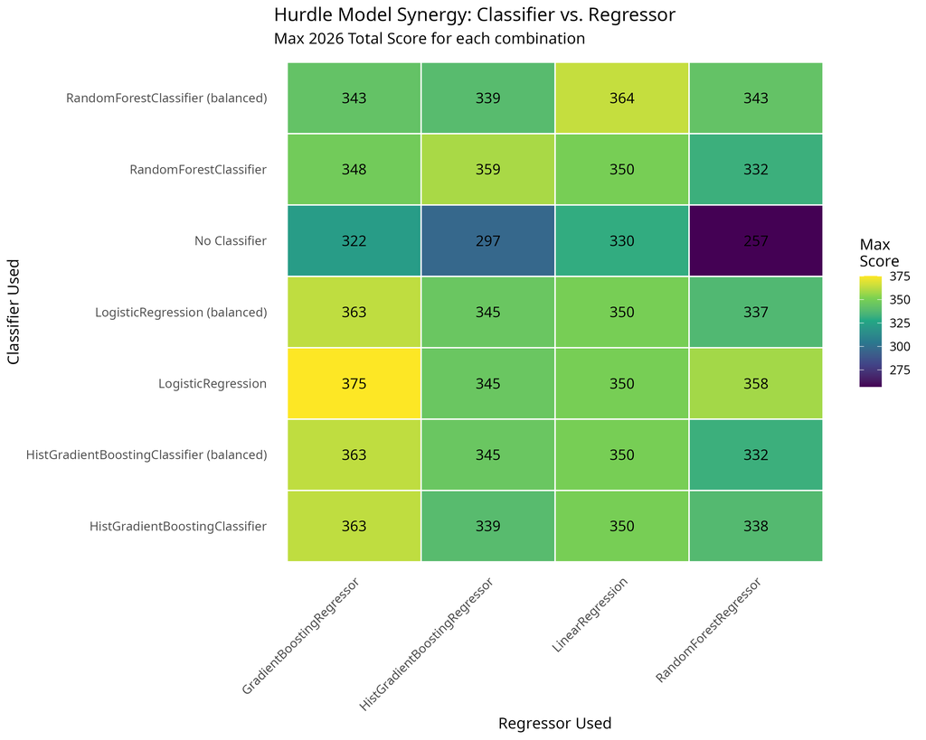

## Possible improvements

### 1. Acknowledgin the rules change in 2023

The rules change in 2023 significantly affects the voting dynamics and criteria for selecting the All-NBA and All-Rookie teams. One of the changes is dropping the requirement for a concrete number of players from each position (e.g., guards, forwards, centers) in the All-NBA teams. Another change is the minimum games played requirement

### 2. Smarter feature selection

The current feature selection is based on domain knowledge and intuition. However, a more systematic approach could be implemented, such as using feature importance from a tree-based model or using a feature selection algorithm.

### 3. Hyperparameter tuning

The current model is trained with default hyperparameters. A more thorough approach would involve using techniques such as grid search or random search to find the optimal hyperparameters for both the classification and regression models.

### 4. Better validation strategy

The current validation is performed on a single season. Theoreticaly, a more robust approach would involve a cross-validation strategy, although because of the 2023 rule, which eliminates requirement for diverse positions across the 5 players in the same team, as well as the recent minimum games played requirement, it is hard to tell haw to acquire a real validation score.

### 5. Statistical significance testing

For the comparison results to be actually meaningful, it would be important to perform statistical significance testing to determine whether the differences in performance between different models and approaches are statistically significant or if they could be due to random chance.